# Telco Customer Churn Prediction

### Numerical Variables vs Target Variable(Churn)

```python
def target_summary_with_num(dataframe,target, numerical_col):
    print(dataframe.groupby(target).agg({numerical_col:"mean"}), end="\n\n")
    print("###################################")


for col in num_cols:
    target_summary_with_num(df,"Churn",col)
```

```
          tenure
Churn
0      37.569965
1      17.979133

###################################
       MonthlyCharges
Churn
0           61.265124
1           74.441332

###################################
       TotalCharges
Churn
0       2549.911442
1       1531.796094

###################################
```

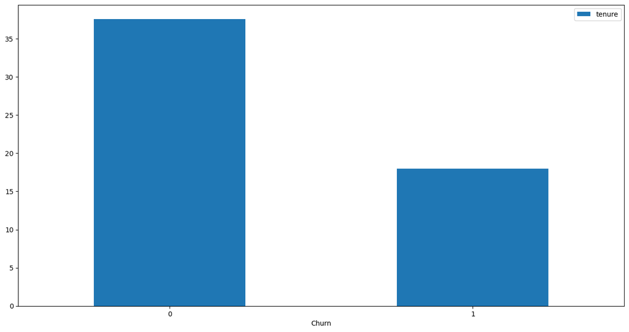

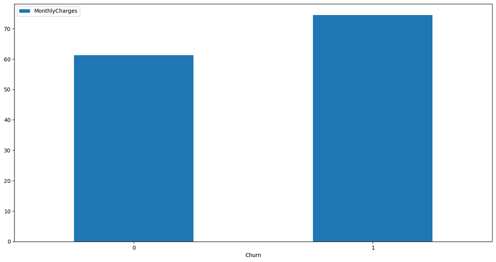

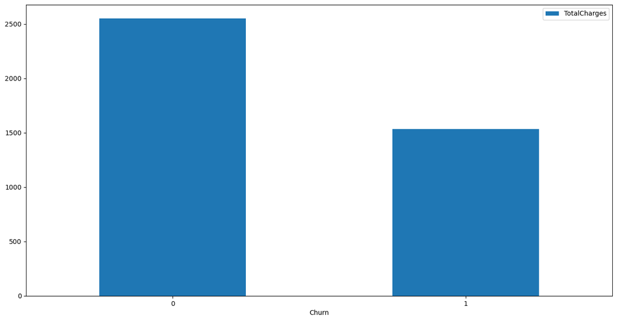

```python
for col in num_cols:
    df.groupby('Churn').agg({col:'mean'}).plot(kind='bar', rot = 0,figsize=(16,8))
```

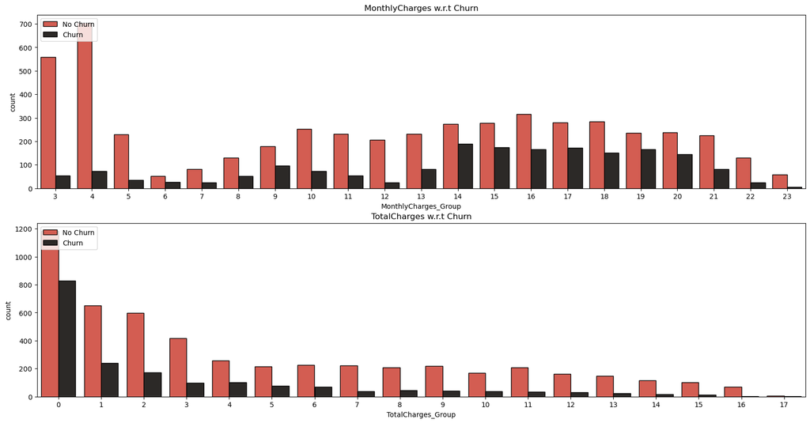

```python
df['MonthlyCharges_Group'] = [int(i / 5) for i in df['MonthlyCharges']]
df['TotalCharges_Group'] = [int(i / 500) for i in df['TotalCharges']]

fig, ax = plt.subplots(nrows = 2,ncols = 1,figsize = (20,10))
for i in range(len(num_cols[1:])):
    plt.subplot(2,1,i+1)
    sns.countplot(x = num_cols[1 + i]+'_Group',data = df,hue = "Churn",palette = colors,edgecolor = 'black')
    plt.legend(['No Churn','Churn'],loc = 'upper left')
    title = num_cols[1 + i] + ' w.r.t Churn'
    plt.title(title);
```

## Numerical features vs Categorical features w.r.t Target variable (Churn)

```python
l1 = ['gender','SeniorCitizen','Partner','Dependents'] # Customer Information
l2 = ['PhoneService','MultipleLines','InternetService','StreamingTV','StreamingMovies',
      'OnlineSecurity','OnlineBackup','DeviceProtection','TechSupport'] # Services Signed Up for!
l3 = ['Contract','PaperlessBilling','PaymentMethod'] # Payment Information
```

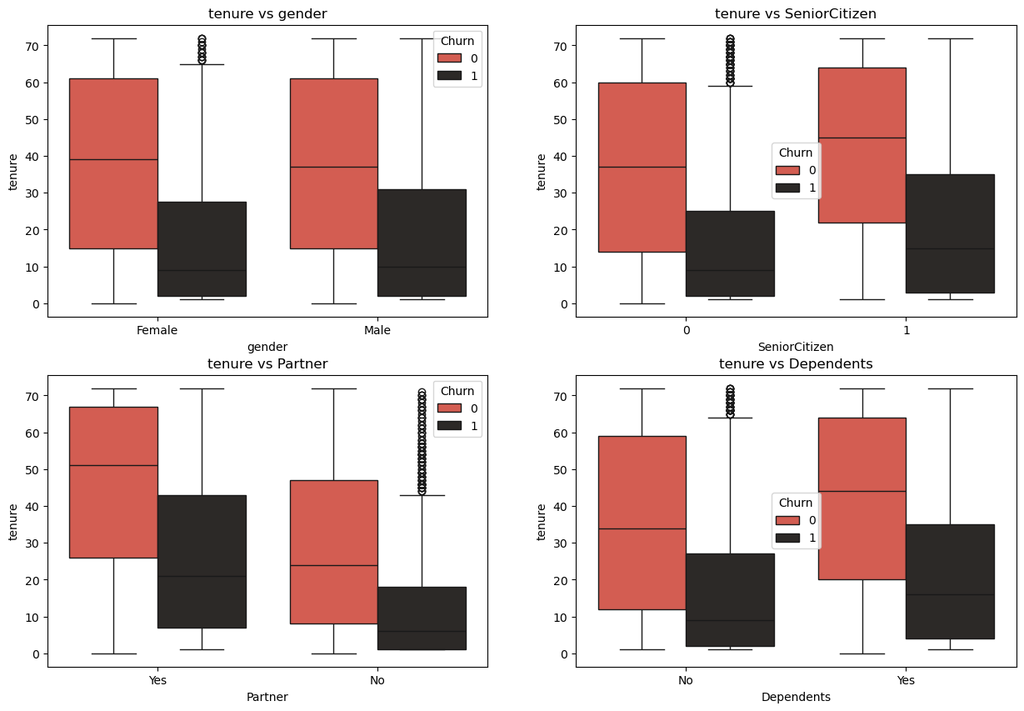

```python
fig = plt.subplots(nrows = 2,ncols = 2,figsize = (15,10))
for i in range(4):
    plt.subplot(2,2,i+1)
    ax = sns.boxplot(x = l1[i],y = 'tenure',data = df,hue = 'Churn',palette = colors);
    plt.title('tenure vs ' + l1[i]);
```

## Observations

- The customer churn graphs for men and women are very similar.
- Senior citizens discontinued their services within a usage duration range of 0 to 35 months. The 20–35 month period appears to be a decision-making phase for senior citizens regarding whether to continue with the service or switch providers.
- Similarly, customers who are business partners continued to use the service for a duration ranging from 5 to 45 months.

### tenure vs Group 2: Services Subscribed by the Customer : PhoneService | MultipleLines | InternetService | StreamingTV | StreamingMovies

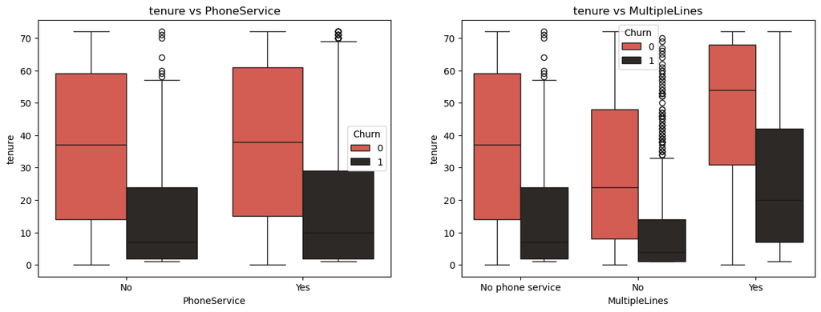

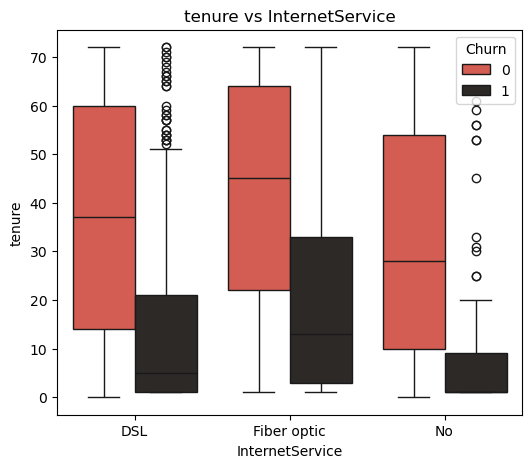

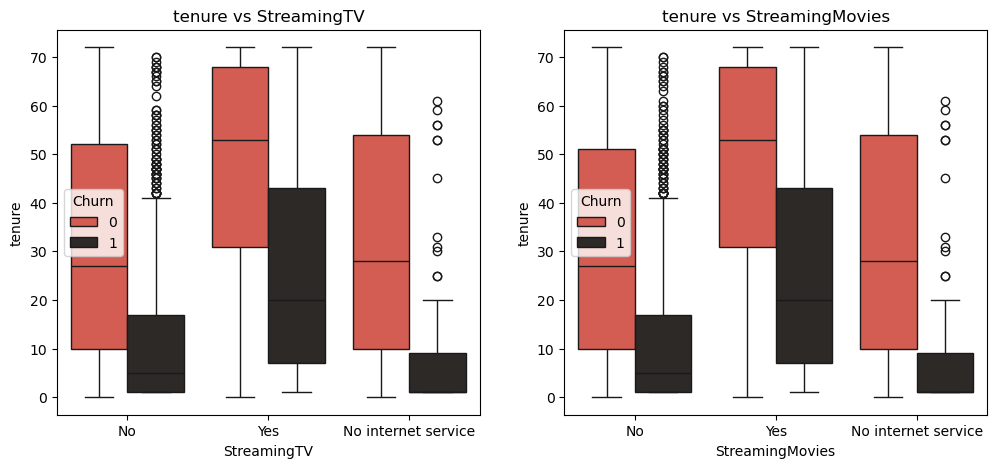

```python
fig = plt.subplots(nrows = 1,ncols = 2,figsize = (15,5))

for i in range(len(l2[0:2])):
    plt.subplot(1,2,i + 1)
    ax = sns.boxplot(x = l2[i],y = 'tenure',data = df,hue = 'Churn',palette = colors);
    plt.title('tenure vs ' + l2[i]);

fig = plt.subplots(nrows = 1, ncols = 1, figsize = (6,5))

plt.subplot(1,1,1)
ax = sns.boxplot(x = l2[2],y = 'tenure',data = df,hue = 'Churn',palette = colors);
plt.title('tenure vs ' + l2[2]);

fig = plt.subplots(nrows = 1,ncols = 2,figsize = (12,5))

for i in range(len(l2[3:5])):
    plt.subplot(1,2,i + 1)
    ax = sns.boxplot(x = l2[i + 3],y = 'tenure',data = df,hue = 'Churn',palette = colors);
    plt.title('tenure vs ' + l2[i + 3]);
```

### Comments

- The presence of "MultipleLines" drives up average monthly charges, regardless of whether customers eventually discontinue their services.
- Regarding the "Tenure vs. PhoneService" graph: the visuals illustrate the presence—or absence—of PhoneService. It appears that these customers were likely not heavy users of telephone services (calls or messaging).
- As for "InternetService": customers seem quite skeptical about the use of Fiber Optic cables, as evidenced by a period of uncertainty lasting approximately 30 to 35 months—before they eventually proceed to upgrade their connection or switch to a new cable service.
- Similarly, with "StreamingTV" and "StreamingMovies," a period of non-usage—spanning roughly 10 to 40 months—can be observed.

### tenure vs Group 2: Services Subscribed by the Customer : OnlineSecurity | OnlineBackup | DeviceProtection | TechSupport

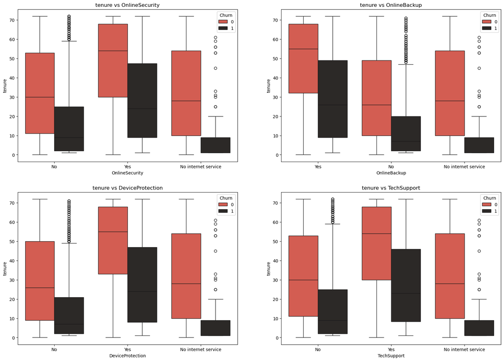

```python
fig = plt.subplots(nrows = 2,ncols = 2,figsize = (20,14))
for i in range(len(l2[-4:])):
    plt.subplot(2,2,i + 1)
    ax = sns.boxplot(x = l2[i - 4],y = 'tenure',data = df,hue = 'Churn',palette = colors);
    plt.title('tenure vs ' + l2[i-4]);
```

### Comments

The average churn duration for OnlineSecurity, OnlineBackup, DeviceProtection, and TechSupport is 25 months. The maximum value for this churn duration is approximately 45 months.

The 30–35 month period is the timeframe during which customers engage in a phone conversation to decide whether to continue with their current services or switch to the features mentioned above!

## tenure vs Group 3 : Contract | PaperlessBilling | PaymentMethod |¶

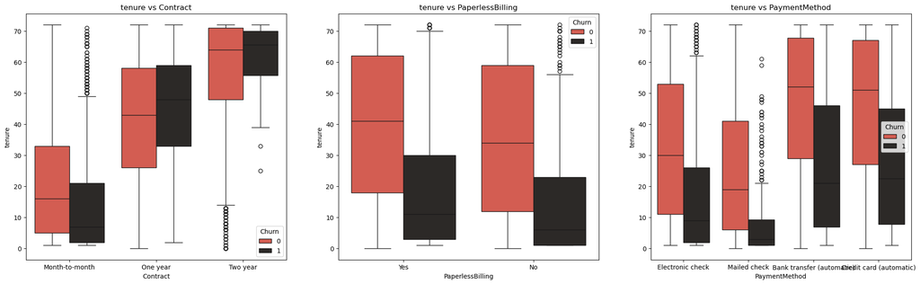

```python
fig = plt.subplots(nrows = 1,ncols = 3,figsize = (25,7))
for i in range(len(l3)):
    plt.subplot(1,3,i + 1)
    ax = sns.boxplot(x = l3[i],y = 'tenure',data = df,hue = 'Churn',palette = colors);
    plt.title('tenure vs ' + l3[i]);
```

## MonthlyCharges vs Group 1 : Customer Information : gender | SeniorCitizen | Partner | Dependents

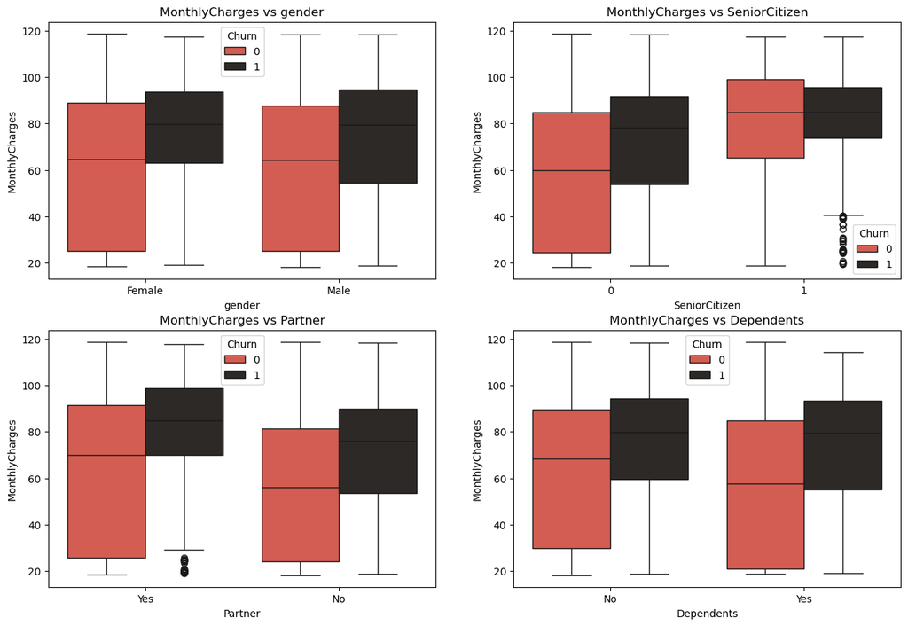

```python
fig = plt.subplots(nrows = 2,ncols = 2,figsize = (15,10))
for i in range(4):
    plt.subplot(2,2,i+1)
    ax = sns.boxplot(x = l1[i],y = 'MonthlyCharges',data = df,hue = 'Churn',palette = colors);
    plt.title('MonthlyCharges vs ' + l1[i]);
```

### MonthlyCharges vs Group 2: Services Subscribed by the Customer : PhoneService | MultipleLines | InternetService | StreamingTV | StreamingMovies

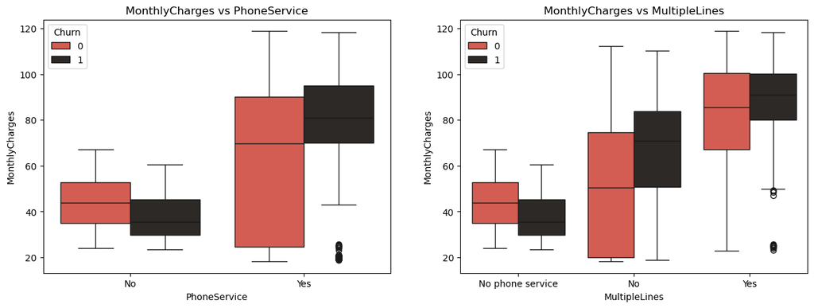

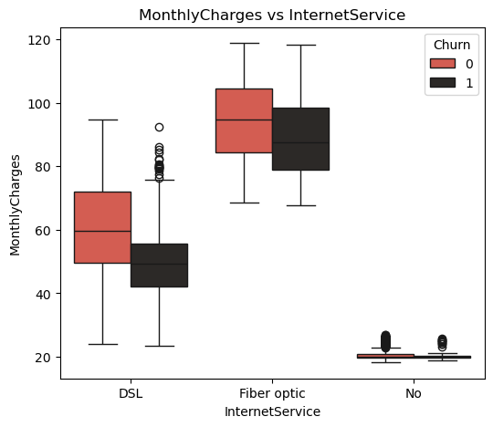

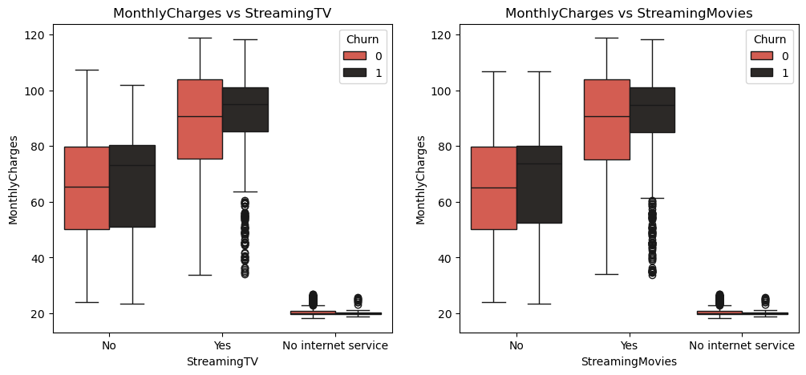

```python
fig = plt.subplots(nrows = 1,ncols = 2,figsize = (15,5))

for i in range(len(l2[0:2])):
    plt.subplot(1,2,i + 1)
    ax = sns.boxplot(x = l2[i],y = 'MonthlyCharges',data = df,hue = 'Churn',palette = colors);
    plt.title('MonthlyCharges vs ' + l2[i]);

fig = plt.subplots(nrows = 1, ncols = 1, figsize = (6,5))

plt.subplot(1,1,1)
ax = sns.boxplot(x = l2[2],y = 'MonthlyCharges',data = df,hue = 'Churn',palette = colors);
plt.title('MonthlyCharges vs ' + l2[2]);

fig = plt.subplots(nrows = 1,ncols = 2,figsize = (12,5))

for i in range(len(l2[3:5])):
    plt.subplot(1,2,i + 1)
    ax = sns.boxplot(x = l2[i + 3],y = 'MonthlyCharges',data = df,hue = 'Churn',palette = colors);
    plt.title('MonthlyCharges vs ' + l2[i + 3]);
```

## Comments

- The monthly fees for Fiber Optic cables are very high. This may be the reason for such a high rate of customer churn.
- Similarly, the monthly fees for StreamingTV and StreamingMovies are also quite high.
- For PhoneService, the range of monthly charges is between 25 and 85; however, customers tend to consider canceling their subscriptions once the monthly charges reach the 75 mark.

## MonthlyCharges vs Group 2: Services Subscribed by the Customer : OnlineSecurity | OnlineBackup | DeviceProtection | TechSupport

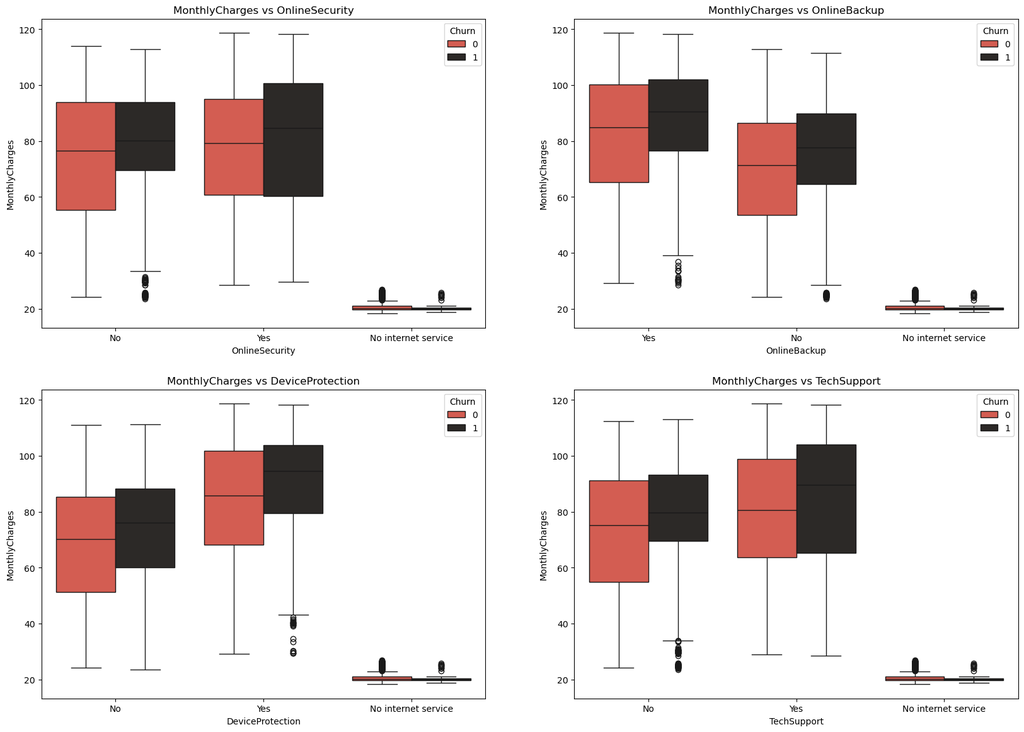

```python
fig = plt.subplots(nrows = 2,ncols = 2,figsize = (20,14))
for i in range(len(l2[-4:])):
    plt.subplot(2,2,i + 1)
    ax = sns.boxplot(x = l2[i - 4],y = 'MonthlyCharges',data = df,hue = 'Churn',palette = colors);
    plt.title('MonthlyCharges vs ' + l2[i-4]);
```

## Comments

- The value range for OnlineSecurity, OnlineBackup, DeviceProtection, and TechSupport is approximately between 50 and 100.
- Customers subscribed to these services are likely not considering canceling their subscriptions—presumably due to the *MonthlyCharges*—because the value range for those who have churned and those who remain active is nearly identical!

### MonthlyCharges vs Group 3 : Contract | PaperlessBilling | PaymentMethod

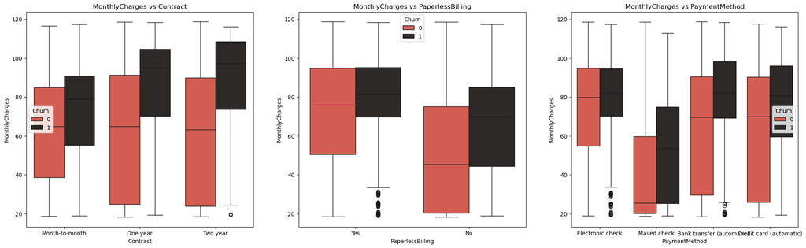

```python
fig = plt.subplots(nrows = 1,ncols = 3,figsize = (25,7))

for i in range(len(l3)):
    plt.subplot(1,3,i + 1)
    ax = sns.boxplot(x = l3[i],y = 'MonthlyCharges',data = df,hue = 'Churn',palette = colors);
    title = 'MonthlyCharges vs ' + l3[i]
    plt.title(title);
```

## TotalCharges vs Group 1 : Customer Information : gender | SeniorCitizen | Partner | Dependents

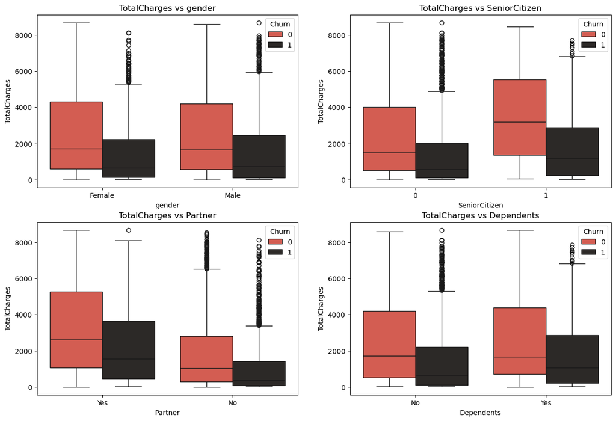

```python
fig = plt.subplots(nrows = 2,ncols = 2,figsize = (15,10))
for i in range(4):
    plt.subplot(2,2,i+1)
    ax = sns.boxplot(x = l1[i],y = 'TotalCharges',data = df,hue = 'Churn',palette = colors);
    plt.title('TotalCharges vs ' + l1[i]);
```

### Comments

- Total Fees are exactly the same for both male and female customers! For Senior Citizens who continue to utilize the service, the initial and final values of the Total Fees are higher.
- The average Total Fee for customers living with their spouses is higher compared to those living alone!

## TotalCharges vs Group 2: Services Subscribed by the Customer : PhoneService | MultipleLines | InternetService | StreamingTV | StreamingMovies

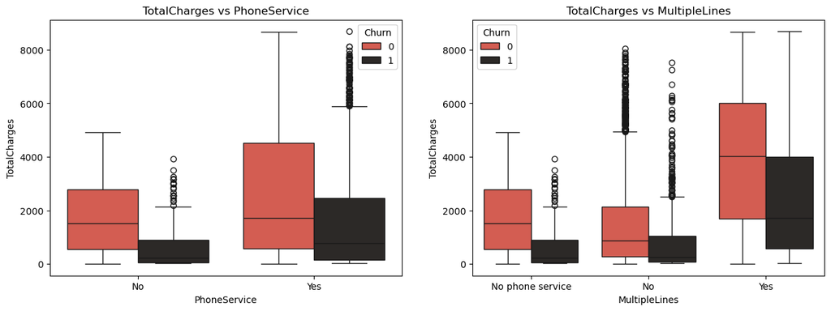

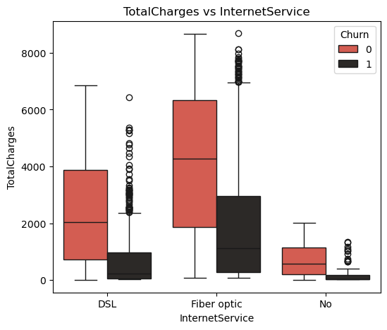

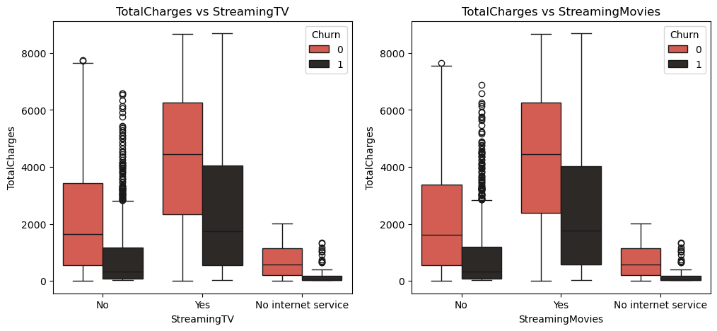

```python
fig = plt.subplots(nrows = 1,ncols = 2,figsize = (15,5))

for i in range(len(l2[0:2])):
    plt.subplot(1,2,i + 1)
    ax = sns.boxplot(x = l2[i],y = 'TotalCharges',data = df,hue = 'Churn',palette = colors);
    plt.title('TotalCharges vs ' + l2[i]);

fig = plt.subplots(nrows = 1, ncols = 1, figsize = (6,5))

plt.subplot(1,1,1)
ax = sns.boxplot(x = l2[2],y = 'TotalCharges',data = df,hue = 'Churn',palette = colors);
plt.title('TotalCharges vs ' + l2[2]);

fig = plt.subplots(nrows = 1,ncols = 2,figsize = (12,5))

for i in range(len(l2[3:5])):
    plt.subplot(1,2,i + 1)
    ax = sns.boxplot(x = l2[i + 3],y = 'TotalCharges',data = df,hue = 'Churn',palette = colors);
    plt.title('TotalCharges vs ' + l2[i + 3]);
```

### Comments

- Total charges for the PhoneService range from 0 to 4000. However, due to these total costs, customers begin to have second thoughts about the PhoneService once the charges reach around 1000.
- Similarly, customers start to hesitate about paying around 2000 for MultipleLines. Yet, some customers appear resigned to the fact that they are paying a sum in the vicinity of 6000 for MultipleLines!
- As for payments related to Fiber Optic cabling, customers tend to test the waters by paying around 2000.
- Customers who continue to subscribe to services—specifically Fiber Optic, StreamingTV, and StreamingMovies—pay between 3000 and 6000.

## TotalCharges vs Group 2: Services Subscribed by the Customer : OnlineSecurity | OnlineBackup | DeviceProtection | TechSupport |

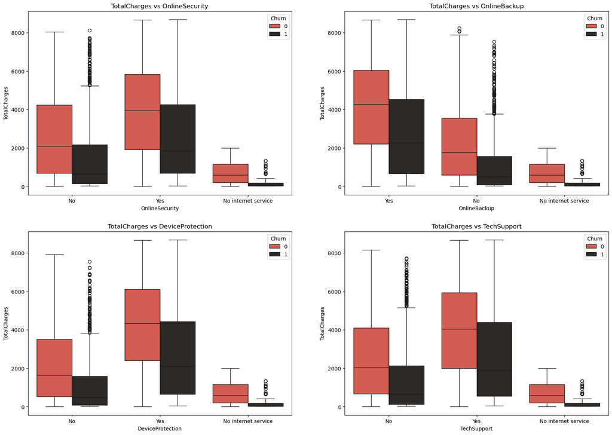

```python
fig = plt.subplots(nrows = 2,ncols = 2,figsize = (20,14))
for i in range(len(l2[-4:])):
    plt.subplot(2,2,i + 1)
    ax = sns.boxplot(x = l2[i - 4],y = 'TotalCharges',data = df,hue = 'Churn',palette = colors);
    plt.title('TotalCharges vs ' + l2[i-4]);
```

Regarding all the features mentioned above, customers began to grow skeptical about paying for them around the year 2000. The median value for these lost customers falls very close to the lower bound of the customers who continue to subscribe to the service.

Customers who do not unsubscribe are willing to pay a Total Fee ranging between 2,000 and 6,000.

## TotalCharges vs Group 3 : Contract | PaperlessBilling | PaymentMethod |¶

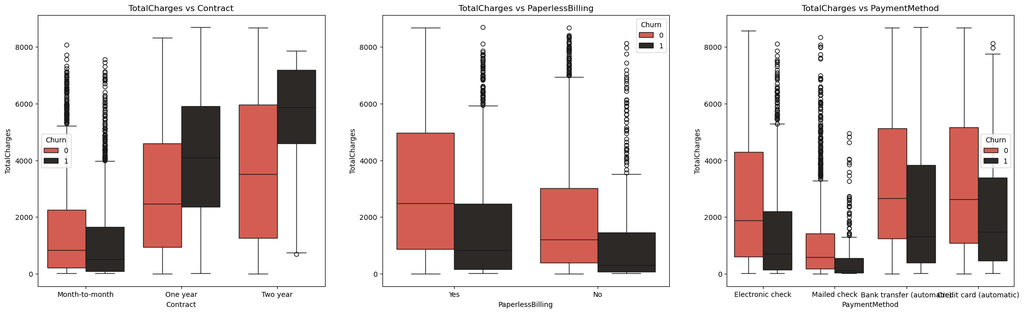

```python
fig = plt.subplots(nrows = 1,ncols = 3,figsize = (25,7))

for i in range(len(l3)):
    plt.subplot(1,3,i + 1)
    ax = sns.boxplot(x = l3[i],y = 'TotalCharges',data = df,hue = 'Churn',palette = colors);
    plt.title('TotalCharges vs ' + l3[i]);
```

### Comments

- The average values for customers who decided to discontinue their one-year and two-year contracted services are notably high, hovering around 4,000 and 6,000. Some customers on two-year contracts even made payments in the vicinity of 7,000.
- Regarding PaymentMethod, while customers tend to be hesitant to use Electronic Check for payments within the shorter range of 0 to 2,000, this range extends to approximately 0 to 4,000 for Bank Transfer (automatic) and Credit Card (automatic).

## Numerical features vs Numerical features w.r.t Target variable (Churn) :

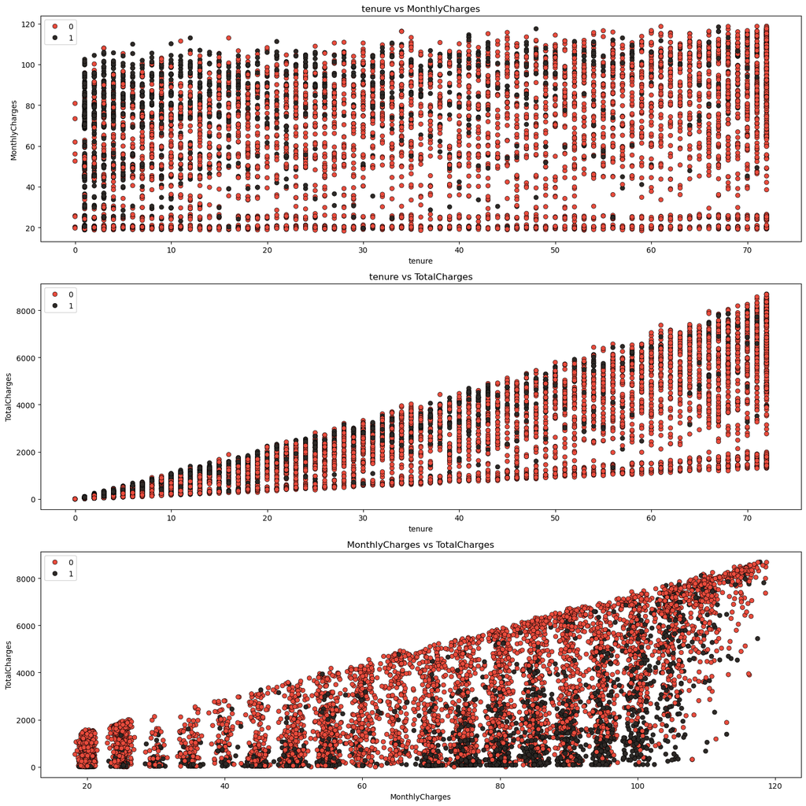

```python
import itertools

pairs = list(itertools.combinations(num_cols, 2))

plt.figure(figsize=(15, 5*len(pairs)))

for idx, (x_col, y_col) in enumerate(pairs, 1):
    plt.subplot(len(pairs), 1, idx)

    sns.scatterplot(
        x=x_col,
        y=y_col,
        data=df,
        hue='Churn',
        palette=colors,
        edgecolor='black'
    )

    plt.title(f"{x_col} vs {y_col}")
    plt.legend(loc='upper left')

plt.tight_layout()
plt.show()
```

### Comments

For a usage duration of 0 to 20 months, customers exhibit significant fluctuation across the entire range of MonthlyCharges values.

During the usage period between 20 and 60 months, customers whose MonthlyCharges values fall within the upper range (70–120) begin to discontinue their services.

Regarding TotalCharges and tenure: as tenure increases, TotalCharges increases as well! The customers who churn are those who incurred the highest monthly charges throughout their usage periods—along with a few customers whose TotalCharges fall within the mid-range.

It appears that once Monthly Charges reached 70 or higher, customers decided to cancel their subscriptions.

# Feature Engineering

```python
from sklearn.preprocessing import MinMaxScaler,StandardScaler
mms = MinMaxScaler() # Normalization
ss = StandardScaler() # Standardization

df.drop(columns = ['MonthlyCharges_Group','TotalCharges_Group'], inplace = True)

df['tenure'] = mms.fit_transform(df[['tenure']])
df['MonthlyCharges'] = mms.fit_transform(df[['MonthlyCharges']])
df['TotalCharges'] = mms.fit_transform(df[['TotalCharges']])
df.head()
```

|  | gender | SeniorCitizen | Partner | Dependents | tenure | PhoneService | MultipleLines | InternetService | OnlineSecurity | OnlineBackup | DeviceProtection | TechSupport | StreamingTV | StreamingMovies | Contract | PaperlessBilling | PaymentMethod | MonthlyCharges | TotalCharges | Churn |
| --- | --- | --- | --- | --- | --- | --- | --- | --- | --- | --- | --- | --- | --- | --- | --- | --- | --- | --- | --- | --- |
| 0 | Female | 0 | Yes | No | 0.013889 | No | No phone service | DSL | No | Yes | No | No | No | No | Month-to-month | Yes | Electronic check | 0.115423 | 0.003437 | 0 |
| 1 | Male | 0 | No | No | 0.472222 | Yes | No | DSL | Yes | No | Yes | No | No | No | One year | No | Mailed check | 0.385075 | 0.217564 | 0 |
| 2 | Male | 0 | No | No | 0.027778 | Yes | No | DSL | Yes | Yes | No | No | No | No | Month-to-month | Yes | Mailed check | 0.354229 | 0.012453 | 1 |
| 3 | Male | 0 | No | No | 0.625000 | No | No phone service | DSL | Yes | No | Yes | Yes | No | No | One year | No | Bank transfer (automatic) | 0.239303 | 0.211951 | 0 |
| 4 | Female | 0 | No | No | 0.027778 | Yes | No | Fiber optic | No | No | No | No | No | No | Month-to-month | Yes | Electronic check | 0.521891 | 0.017462 | 1 |

### Comments

A machine learning model does not understand the units of the feature values. It treats the input merely as a numerical value, without grasping its actual meaning. Consequently, scaling the data becomes a necessity.

- We have two options for data scaling: 1) Normalization and 2) Standardization.
- Since most algorithms assume that data follows a normal (Gaussian) distribution, normalization is applied to features that do not exhibit a normal distribution; conversely, standardization is applied to normally distributed features whose values are either significantly larger or smaller when compared to other features.
- Normalization: The `tenure`, `MonthlyCharges`, and `TotalCharges` features were normalized, as they exhibited a right-skewed and bimodal data distribution.
- Standardization: For the data mentioned above, no features were standardized.

### Correlation Matrix

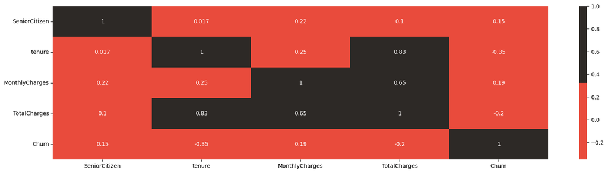

```python
plt.figure(figsize = (20,5))
sns.heatmap(df.corr(numeric_only=True), cmap=colors, annot=True)
```

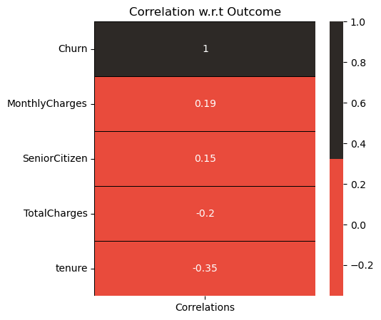

```python
corr = df.corr(numeric_only=True)['Churn'].sort_values(ascending=False).to_frame()
corr.columns = ['Correlations']
plt.subplots(figsize = (5,5))
sns.heatmap(corr,annot = True,cmap = colors,linewidths = 0.4,linecolor = 'black');
plt.title('Correlation w.r.t Outcome');
```

### Feature Selection

```python
from sklearn.preprocessing import LabelEncoder
le = LabelEncoder()

df = df.copy(deep = True)
text_data_features = [i for i in list(df.columns) if i not in list(df.describe().columns)]

print('Label Encoder Transformation')
for i in text_data_features :
    df[i] = le.fit_transform(df[i])
    print(i,' : ',df[i].unique(),' = ',le.inverse_transform(df[i].unique()))
```

```
Label Encoder Transformation
gender  :  [0 1]  =  ['Female' 'Male']
Partner  :  [1 0]  =  ['Yes' 'No']
Dependents  :  [0 1]  =  ['No' 'Yes']
PhoneService  :  [0 1]  =  ['No' 'Yes']
MultipleLines  :  [1 0 2]  =  ['No phone service' 'No' 'Yes']
InternetService  :  [0 1 2]  =  ['DSL' 'Fiber optic' 'No']
OnlineSecurity  :  [0 2 1]  =  ['No' 'Yes' 'No internet service']
OnlineBackup  :  [2 0 1]  =  ['Yes' 'No' 'No internet service']
DeviceProtection  :  [0 2 1]  =  ['No' 'Yes' 'No internet service']
TechSupport  :  [0 2 1]  =  ['No' 'Yes' 'No internet service']
StreamingTV  :  [0 2 1]  =  ['No' 'Yes' 'No internet service']
StreamingMovies  :  [0 2 1]  =  ['No' 'Yes' 'No internet service']
Contract  :  [0 1 2]  =  ['Month-to-month' 'One year' 'Two year']
PaperlessBilling  :  [1 0]  =  ['Yes' 'No']
PaymentMethod  :  [2 3 0 1]  =  ['Electronic check' 'Mailed check' 'Bank transfer (automatic)'
 'Credit card (automatic)']
```

```python
df.head()
```

|  | gender | SeniorCitizen | Partner | Dependents | tenure | PhoneService | MultipleLines | InternetService | OnlineSecurity | OnlineBackup | DeviceProtection | TechSupport | StreamingTV | StreamingMovies | Contract | PaperlessBilling | PaymentMethod | MonthlyCharges | TotalCharges | Churn |
| --- | --- | --- | --- | --- | --- | --- | --- | --- | --- | --- | --- | --- | --- | --- | --- | --- | --- | --- | --- | --- |
| 0 | 0 | 0 | 1 | 0 | 0.013889 | 0 | 1 | 0 | 0 | 2 | 0 | 0 | 0 | 0 | 0 | 1 | 2 | 0.115423 | 0.003437 | 0 |
| 1 | 1 | 0 | 0 | 0 | 0.472222 | 1 | 0 | 0 | 2 | 0 | 2 | 0 | 0 | 0 | 1 | 0 | 3 | 0.385075 | 0.217564 | 0 |
| 2 | 1 | 0 | 0 | 0 | 0.027778 | 1 | 0 | 0 | 2 | 2 | 0 | 0 | 0 | 0 | 0 | 1 | 3 | 0.354229 | 0.012453 | 1 |
| 3 | 1 | 0 | 0 | 0 | 0.625000 | 0 | 1 | 0 | 2 | 0 | 2 | 2 | 0 | 0 | 1 | 0 | 0 | 0.239303 | 0.211951 | 0 |
| 4 | 0 | 0 | 0 | 0 | 0.027778 | 1 | 0 | 1 | 0 | 0 | 0 | 0 | 0 | 0 | 0 | 1 | 2 | 0.521891 | 0.017462 | 1 |

```python
from sklearn.feature_selection import SelectKBest
from sklearn.feature_selection import chi2,mutual_info_classif
```

```python
df.loc[:,cat_cols]
```

|  | gender | Partner | Dependents | PhoneService | MultipleLines | InternetService | OnlineSecurity | OnlineBackup | DeviceProtection | TechSupport | StreamingTV | StreamingMovies | Contract | PaperlessBilling | PaymentMethod | Churn | SeniorCitizen |
| --- | --- | --- | --- | --- | --- | --- | --- | --- | --- | --- | --- | --- | --- | --- | --- | --- | --- |
| 0 | 0 | 1 | 0 | 0 | 1 | 0 | 0 | 2 | 0 | 0 | 0 | 0 | 0 | 1 | 2 | 0 | 0 |
| 1 | 1 | 0 | 0 | 1 | 0 | 0 | 2 | 0 | 2 | 0 | 0 | 0 | 1 | 0 | 3 | 0 | 0 |
| 2 | 1 | 0 | 0 | 1 | 0 | 0 | 2 | 2 | 0 | 0 | 0 | 0 | 0 | 1 | 3 | 1 | 0 |
| 3 | 1 | 0 | 0 | 0 | 1 | 0 | 2 | 0 | 2 | 2 | 0 | 0 | 1 | 0 | 0 | 0 | 0 |
| 4 | 0 | 0 | 0 | 1 | 0 | 1 | 0 | 0 | 0 | 0 | 0 | 0 | 0 | 1 | 2 | 1 | 0 |
| ... | ... | ... | ... | ... | ... | ... | ... | ... | ... | ... | ... | ... | ... | ... | ... | ... | ... |
| 7038 | 1 | 1 | 1 | 1 | 2 | 0 | 2 | 0 | 2 | 2 | 2 | 2 | 1 | 1 | 3 | 0 | 0 |
| 7039 | 0 | 1 | 1 | 1 | 2 | 1 | 0 | 2 | 2 | 0 | 2 | 2 | 1 | 1 | 1 | 0 | 0 |
| 7040 | 0 | 1 | 1 | 0 | 1 | 0 | 2 | 0 | 0 | 0 | 0 | 0 | 0 | 1 | 2 | 0 | 0 |
| 7041 | 1 | 1 | 0 | 1 | 2 | 1 | 0 | 0 | 0 | 0 | 0 | 0 | 0 | 1 | 3 | 1 | 1 |
| 7042 | 1 | 0 | 0 | 1 | 0 | 1 | 2 | 0 | 2 | 2 | 2 | 2 | 2 | 1 | 0 | 0 | 0 |

7043 rows × 17 columns

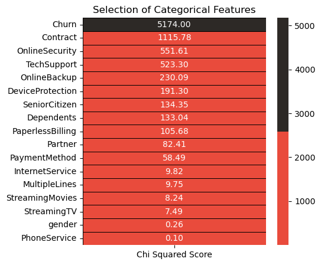

```python
features = df.loc[:,cat_cols]
target = df.loc[:,'Churn']

best_features = SelectKBest(score_func = chi2,k = 'all')
fit = best_features.fit(features,target)

featureScores = pd.DataFrame(data = fit.scores_,index = list(features.columns),columns = ['Chi Squared Score'])

plt.subplots(figsize = (5,5))
sns.heatmap(featureScores.sort_values(ascending = False,by = 'Chi Squared Score'),annot = True,cmap = colors,linewidths = 0.4,linecolor = 'black',fmt = '.2f');
plt.title('Selection of Categorical Features');
```

- Phone Service, Gender, Streaming TV, Streaming Movies, Multiple Lines, and Internet Service exhibit a very low correlation with Churn.

### Feature Selection for Numerical Features :¶

```python
from sklearn.feature_selection import f_classif
```

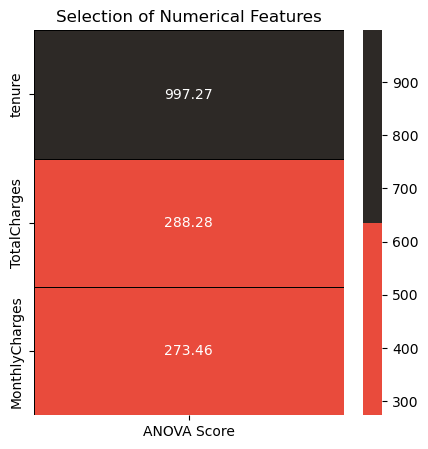

```python
features = df.loc[:,num_cols]
target = df.loc[:,'Churn']

best_features = SelectKBest(score_func = f_classif,k = 'all')
fit = best_features.fit(features,target)

featureScores = pd.DataFrame(data = fit.scores_,index = list(features.columns),columns = ['ANOVA Score'])

plt.subplots(figsize = (5,5))
sns.heatmap(featureScores.sort_values(ascending = False,by = 'ANOVA Score'),annot = True,cmap = colors,linewidths = 0.4,linecolor = 'black',fmt = '.2f');
plt.title('Selection of Numerical Features');
```

### Comments

According to the ANOVA test, the higher the ANOVA score, the greater the importance of the feature.

Based on the results above, we should include all numerical features for modeling.

```python
df.drop(columns = ['PhoneService', 'gender','StreamingTV','StreamingMovies','MultipleLines','InternetService'],inplace = True)
df.head()
```

|  | SeniorCitizen | Partner | Dependents | tenure | OnlineSecurity | OnlineBackup | DeviceProtection | TechSupport | Contract | PaperlessBilling | PaymentMethod | MonthlyCharges | TotalCharges | Churn |
| --- | --- | --- | --- | --- | --- | --- | --- | --- | --- | --- | --- | --- | --- | --- |
| 0 | 0 | 1 | 0 | 0.013889 | 0 | 2 | 0 | 0 | 0 | 1 | 2 | 0.115423 | 0.003437 | 0 |
| 1 | 0 | 0 | 0 | 0.472222 | 2 | 0 | 2 | 0 | 1 | 0 | 3 | 0.385075 | 0.217564 | 0 |
| 2 | 0 | 0 | 0 | 0.027778 | 2 | 2 | 0 | 0 | 0 | 1 | 3 | 0.354229 | 0.012453 | 1 |
| 3 | 0 | 0 | 0 | 0.625000 | 2 | 0 | 2 | 2 | 1 | 0 | 0 | 0.239303 | 0.211951 | 0 |
| 4 | 0 | 0 | 0 | 0.027778 | 0 | 0 | 0 | 0 | 0 | 1 | 2 | 0.521891 | 0.017462 | 1 |

### Balancing

There are two options for handling imbalanced data:

- Undersampling: Prune the majority class instances of the target variable.
- Oversampling: Boost the minority class instances of the target variable to match the majority class.
- After experimenting with both undersampling and oversampling, we decided to proceed with oversampling!

We will use `imblearn` for data balancing. pip command: `pip install imbalanced-learn`

```python
import imblearn
from collections import Counter
from imblearn.over_sampling import SMOTE
from imblearn.under_sampling import RandomUnderSampler
from imblearn.pipeline import Pipeline
```

```python
over = SMOTE(sampling_strategy = 1)

f1 = df.iloc[:,:13].values
t1 = df.iloc[:,13].values

f1, t1 = over.fit_resample(f1, t1)
Counter(t1)
```

```
Counter({np.int64(0): 5174, np.int64(1): 5174})
```

# MODELING

```python
from sklearn.model_selection import train_test_split
from sklearn.metrics import confusion_matrix
from sklearn.metrics import roc_auc_score
from sklearn.metrics import RocCurveDisplay
from sklearn.model_selection import cross_val_score
from sklearn.model_selection import GridSearchCV
from sklearn.metrics import classification_report
from sklearn.metrics import accuracy_score
from sklearn.model_selection import RepeatedStratifiedKFold
from sklearn.metrics import precision_recall_curve
```

```python
x_train, x_test, y_train, y_test = train_test_split(f1, t1, test_size = 0.20, random_state = 2)
```

```python
def model(classifier,x_train,y_train,x_test,y_test):

    classifier.fit(x_train,y_train)
    prediction = classifier.predict(x_test)
    cv = RepeatedStratifiedKFold(n_splits = 10,n_repeats = 3,random_state = 1)
    print("Cross Validation Score : ",'{0:.2%}'.format(cross_val_score(classifier,x_train,y_train,cv = cv,scoring = 'roc_auc').mean()))
    print("ROC_AUC Score : ",'{0:.2%}'.format(roc_auc_score(y_test,prediction)))
    plt.show()

def model_evaluation(classifier,x_test,y_test):

    # Confusion Matrix
    cm = confusion_matrix(y_test,classifier.predict(x_test))
    names = ['True Neg','False Pos','False Neg','True Pos']
    counts = [value for value in cm.flatten()]
    percentages = ['{0:.2%}'.format(value) for value in cm.flatten()/np.sum(cm)]
    labels = [f'{v1}\n{v2}\n{v3}' for v1, v2, v3 in zip(names,counts,percentages)]
    labels = np.asarray(labels).reshape(2,2)
    sns.heatmap(cm,annot = labels,cmap = 'Blues',fmt ='')

    # Classification Report
    print(classification_report(y_test,classifier.predict(x_test)))
```

### 1-) XGB Classifier

```python
from xgboost import XGBClassifier

classifier_xgb = XGBClassifier(learning_rate= 0.01,max_depth = 3,n_estimators = 1000)
```

```python
model(classifier_xgb,x_train,y_train,x_test,y_test)
```

```
Cross Validation Score :  90.14%
ROC_AUC Score :  82.96%
```

```
              precision    recall  f1-score   support

           0       0.86      0.79      0.82      1040
           1       0.81      0.87      0.83      1030

    accuracy                           0.83      2070
   macro avg       0.83      0.83      0.83      2070
weighted avg       0.83      0.83      0.83      2070
```

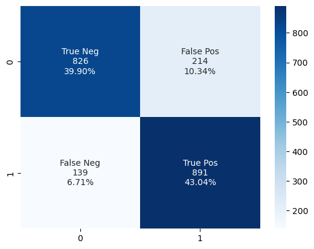

```python
model_evaluation(classifier_xgb,x_test,y_test)
```

### 2) LGBM Classifier

```python
from lightgbm import LGBMClassifier

classifier_lgbm = LGBMClassifier(learning_rate= 0.01,max_depth = 3,n_estimators = 1000, force_col_wise='true',verbose=-1)
```

```python
import warnings
warnings.filterwarnings('ignore')

model(classifier_lgbm,x_train,y_train,x_test,y_test)
```

```
Cross Validation Score :  90.35%
ROC_AUC Score :  83.26%
```

```
              precision    recall  f1-score   support

           0       0.86      0.79      0.83      1040
           1       0.81      0.87      0.84      1030

    accuracy                           0.83      2070
   macro avg       0.83      0.83      0.83      2070
weighted avg       0.83      0.83      0.83      2070
```

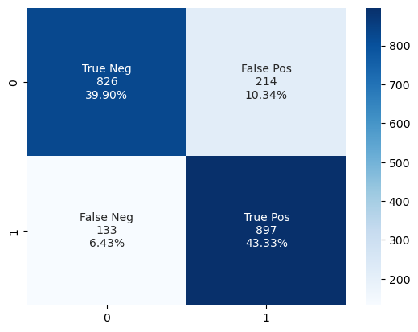

```python
warnings.filterwarnings('ignore')
model_evaluation(classifier_lgbm,x_test,y_test)
```

## Random Forest Classifier

```python
from sklearn.ensemble import RandomForestClassifier
classifier_rf = RandomForestClassifier(max_depth = 4,random_state = 0)
```

```python
model(classifier_rf,x_train,y_train,x_test,y_test)
```

```
Cross Validation Score :  85.59%
ROC_AUC Score :  78.53%
```

```
              precision    recall  f1-score   support

           0       0.83      0.72      0.77      1040
           1       0.75      0.85      0.80      1030

    accuracy                           0.79      2070
   macro avg       0.79      0.79      0.78      2070
weighted avg       0.79      0.79      0.78      2070
```

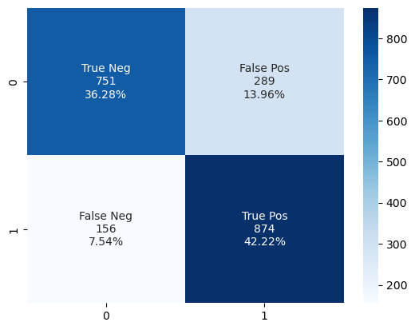

```python
model_evaluation(classifier_rf,x_test,y_test)
```

# Decision Tree Classifier

```python
from sklearn.tree import DecisionTreeClassifier
classifier_dt = DecisionTreeClassifier(random_state = 1000,max_depth = 4,min_samples_leaf = 1)
```

```python
model(classifier_dt,x_train,y_train,x_test,y_test)
```

```
Cross Validation Score :  84.23%
ROC_AUC Score :  76.72%
```

```
              precision    recall  f1-score   support

           0       0.84      0.66      0.74      1040
           1       0.72      0.88      0.79      1030

    accuracy                           0.77      2070
   macro avg       0.78      0.77      0.76      2070
weighted avg       0.78      0.77      0.76      2070
```

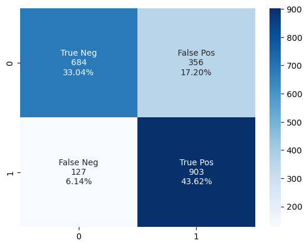

```python
model_evaluation(classifier_dt,x_test,y_test)
```

```python
import warnings
warnings.filterwarnings('ignore')
```

```python
print("Before preprocessing:", df.shape)
print("Churn unique BEFORE cleaning:", df['Churn'].unique())
```

```
Before preprocessing: (7043, 14)
Churn unique BEFORE cleaning: [0 1]
```

```python
import pandas as pd
df = pd.read_csv("WA_Fn-UseC_-Telco-Customer-Churn.csv")
print(df.head())
```

```
   customerID  gender  SeniorCitizen Partner Dependents  tenure PhoneService  \
0  7590-VHVEG  Female              0     Yes         No       1           No
1  5575-GNVDE    Male              0      No         No      34          Yes
2  3668-QPYBK    Male              0      No         No       2          Yes
3  7795-CFOCW    Male              0      No         No      45           No
4  9237-HQITU  Female              0      No         No       2          Yes

      MultipleLines InternetService OnlineSecurity  ... DeviceProtection  \
0  No phone service             DSL             No  ...               No
1                No             DSL            Yes  ...              Yes
2                No             DSL            Yes  ...               No
3  No phone service             DSL            Yes  ...              Yes
4                No     Fiber optic             No  ...               No

  TechSupport StreamingTV StreamingMovies        Contract PaperlessBilling  \
0          No          No              No  Month-to-month              Yes
1          No          No              No        One year               No
2          No          No              No  Month-to-month              Yes
3         Yes          No              No        One year               No
4          No          No              No  Month-to-month              Yes

               PaymentMethod MonthlyCharges  TotalCharges Churn
0           Electronic check          29.85         29.85    No
1               Mailed check          56.95        1889.5    No
2               Mailed check          53.85        108.15   Yes
3  Bank transfer (automatic)          42.30       1840.75    No
4           Electronic check          70.70        151.65   Yes

[5 rows x 21 columns]
```

```python
import pandas as pd
df = pd.read_csv("WA_Fn-UseC_-Telco-Customer-Churn.csv")
print(df.head())
```

```
   customerID  gender  SeniorCitizen Partner Dependents  tenure PhoneService  \
0  7590-VHVEG  Female              0     Yes         No       1           No
1  5575-GNVDE    Male              0      No         No      34          Yes
2  3668-QPYBK    Male              0      No         No       2          Yes
3  7795-CFOCW    Male              0      No         No      45           No
4  9237-HQITU  Female              0      No         No       2          Yes

      MultipleLines InternetService OnlineSecurity  ... DeviceProtection  \
0  No phone service             DSL             No  ...               No
1                No             DSL            Yes  ...              Yes
2                No             DSL            Yes  ...               No
3  No phone service             DSL            Yes  ...              Yes
4                No     Fiber optic             No  ...               No

  TechSupport StreamingTV StreamingMovies        Contract PaperlessBilling  \
0          No          No              No  Month-to-month              Yes
1          No          No              No        One year               No
2          No          No              No  Month-to-month              Yes
3         Yes          No              No        One year               No
4          No          No              No  Month-to-month              Yes

               PaymentMethod MonthlyCharges  TotalCharges Churn
0           Electronic check          29.85         29.85    No
1               Mailed check          56.95        1889.5    No
2               Mailed check          53.85        108.15   Yes
3  Bank transfer (automatic)          42.30       1840.75    No
4           Electronic check          70.70        151.65   Yes

[5 rows x 21 columns]
```

```
Original shape: (7043, 21)
After preprocessing: (7043, 31)
X shape: (7043, 30)
y shape: (7043,)
Churn distribution:
 Churn
0    5174
1    1869
Name: count, dtype: int64

Accuracy: 0.5755855216465579
Recall (Churn): 0.9598930481283422
ROC-AUC: 0.8401095352502002

Classification Report:

              precision    recall  f1-score   support

           0       0.97      0.44      0.60      1035
           1       0.38      0.96      0.55       374

    accuracy                           0.58      1409
   macro avg       0.67      0.70      0.57      1409
weighted avg       0.81      0.58      0.59      1409
```

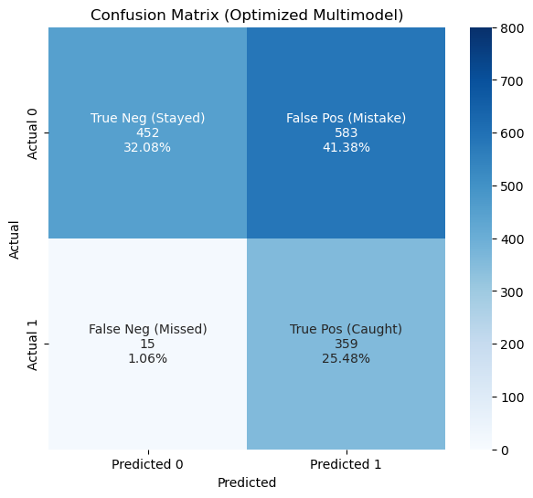

```python
# =========================
# 0. Imports
# =========================
import warnings
warnings.filterwarnings('ignore')

import numpy as np
import pandas as pd
import seaborn as sns
import matplotlib.pyplot as plt

from sklearn.model_selection import train_test_split
from sklearn.metrics import accuracy_score, classification_report, roc_auc_score, confusion_matrix, recall_score
from sklearn.preprocessing import StandardScaler
from sklearn.linear_model import LogisticRegression
from sklearn.ensemble import RandomForestClassifier, StackingClassifier

from xgboost import XGBClassifier
from lightgbm import LGBMClassifier

from imblearn.over_sampling import SMOTE
from imblearn.pipeline import Pipeline as ImbPipeline


print("Original shape:", df.shape)

# =========================
# 2. CLEAN DATA (SAFE)
# =========================

# Drop ID
if 'customerID' in df.columns:
    df = df.drop('customerID', axis=1)

# Fix TotalCharges
df['TotalCharges'] = pd.to_numeric(df['TotalCharges'], errors='coerce')
df['TotalCharges'].fillna(df['TotalCharges'].median(), inplace=True)

# Fix Churn (ONLY if string)
if df['Churn'].dtype == 'object':
    df['Churn'] = df['Churn'].str.strip()
    df['Churn'] = df['Churn'].map({'Yes':1, 'No':0})

# Convert categorical → numeric
df = pd.get_dummies(df, drop_first=True)

# Reset index
df = df.reset_index(drop=True)

print("After preprocessing:", df.shape)

# =========================
# 3. FEATURES & TARGET
# =========================
X = df.drop('Churn', axis=1)
y = df['Churn']

print("X shape:", X.shape)
print("y shape:", y.shape)
print("Churn distribution:\n", y.value_counts())

# =========================
# 4. TRAIN TEST SPLIT
# =========================
X_train, X_test, y_train, y_test = train_test_split(
    X, y, test_size=0.2, stratify=y, random_state=42
)

# Ratio for imbalance
ratio = (y_train == 0).sum() / (y_train == 1).sum()

# =========================
# 5. MODELS (OPTIMIZED)
# =========================
xgb = XGBClassifier(
    n_estimators=150,
    max_depth=4,
    learning_rate=0.05,
    scale_pos_weight=ratio * 1.5,
    eval_metric='logloss'
)

lgbm = LGBMClassifier(
    n_estimators=150,
    learning_rate=0.05,
    class_weight='balanced'
)

rf = RandomForestClassifier(
    n_estimators=150,
    max_depth=10,
    class_weight='balanced_subsample',
    random_state=42
)

# =========================
# 6. STACKING MODEL
# =========================
stack = StackingClassifier(
    estimators=[
        ('xgb', xgb),
        ('lgbm', lgbm),
        ('rf', rf)
    ],
    final_estimator=LogisticRegression(class_weight='balanced', C=0.1),
    cv=3,          # reduced for speed
    n_jobs=1,      # prevent lag
    stack_method='predict_proba'
)

# =========================
# 7. PIPELINE WITH SMOTE
# =========================
pipeline = ImbPipeline([
    ('scaler', StandardScaler()),
    ('smote', SMOTE(sampling_strategy=0.8, random_state=42)),
    ('model', stack)
])

# =========================
# 8. TRAIN
# =========================
pipeline.fit(X_train, y_train)

# =========================
# 9. PREDICTION
# =========================
y_proba = pipeline.predict_proba(X_test)[:, 1]

#  Threshold tuning (increase TP, reduce FN)
threshold = 0.1
y_pred = (y_proba >= threshold).astype(int)

# =========================
# 10. EVALUATION
# =========================
print("\nAccuracy:", accuracy_score(y_test, y_pred))
print("Recall (Churn):", recall_score(y_test, y_pred))
print("ROC-AUC:", roc_auc_score(y_test, y_proba))

print("\nClassification Report:\n")
print(classification_report(y_test, y_pred))

# =========================
# 11. CONFUSION MATRIX
# =========================
cm = confusion_matrix(y_test, y_pred)

TN, FP, FN, TP = cm.ravel()
total = cm.sum()

labels = [
    f"True Neg (Stayed)\n{TN}\n{TN/total:.2%}",
    f"False Pos (Mistake)\n{FP}\n{FP/total:.2%}",
    f"False Neg (Missed)\n{FN}\n{FN/total:.2%}",
    f"True Pos (Caught)\n{TP}\n{TP/total:.2%}"
]

labels = np.array(labels).reshape(2,2)

plt.figure(figsize=(7,6))
sns.heatmap(cm, annot=labels, fmt='', cmap='Blues',
            vmin=0, vmax=800,
            xticklabels=['Predicted 0', 'Predicted 1'],
            yticklabels=['Actual 0', 'Actual 1'])

plt.xlabel('Predicted')
plt.ylabel('Actual')
plt.title('Confusion Matrix (Optimized Multimodel)')
plt.show()
```

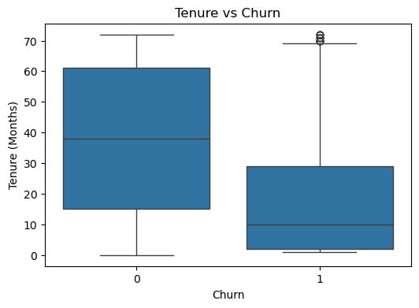

```python
plt.figure(figsize=(6,4))
sns.boxplot(x='Churn', y='tenure', data=df)

plt.title('Tenure vs Churn')
plt.xlabel('Churn')
plt.ylabel('Tenure (Months)')
plt.show()
```

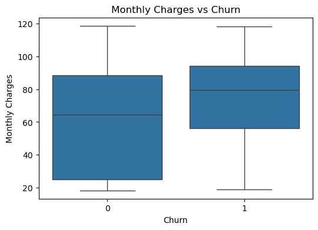

```python
plt.figure(figsize=(6,4))
sns.boxplot(x='Churn', y='MonthlyCharges', data=df)

plt.title('Monthly Charges vs Churn')
plt.xlabel('Churn')
plt.ylabel('Monthly Charges')
plt.show()
```

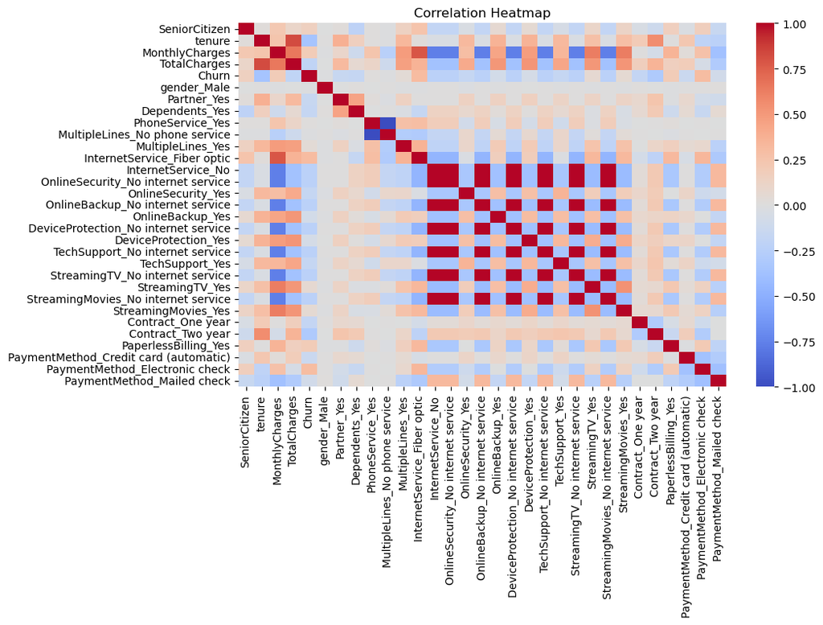

```python
import pandas as pd

plt.figure(figsize=(10,6))
sns.heatmap(df.corr(), cmap='coolwarm')

plt.title('Correlation Heatmap')
plt.show()
```

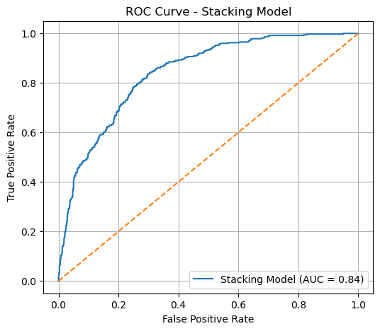

```python
from sklearn.metrics import roc_curve, auc

fpr, tpr, thresholds = roc_curve(y_test, y_proba)
roc_auc = auc(fpr, tpr)

plt.figure(figsize=(6,5))
plt.plot(fpr, tpr, label=f'Stacking Model (AUC = {roc_auc:.2f})')
plt.plot([0,1], [0,1], linestyle='--')

plt.xlabel('False Positive Rate')
plt.ylabel('True Positive Rate')
plt.title('ROC Curve - Stacking Model')
plt.legend()
plt.grid()
plt.show()
```

```python
from sklearn.ensemble import VotingClassifier

from sklearn.linear_model import LogisticRegression
from sklearn.tree import DecisionTreeClassifier
from sklearn.ensemble import RandomForestClassifier

model1 = LogisticRegression(max_iter=1000)
model2 = DecisionTreeClassifier()
model3 = RandomForestClassifier()

voting_model = VotingClassifier(
    estimators=[
        ('lr', model1),
        ('dt', model2),
        ('rf', model3)
    ],
    voting='hard'
)

voting_model.fit(X_train, y_train)

y_pred_vote = voting_model.predict(X_test)

from sklearn.metrics import accuracy_score
print("Voting Classifier Accuracy:", accuracy_score(y_test, y_pred_vote))
```

```
Voting Classifier Accuracy: 0.7970191625266146
```

```python
y_pred_vote = voting_model.predict(X_test)
```

```python
from sklearn.metrics import confusion_matrix

cm_vote = confusion_matrix(y_test, y_pred_vote)
print(cm_vote)
```

```
[[932 103]
 [183 191]]
```

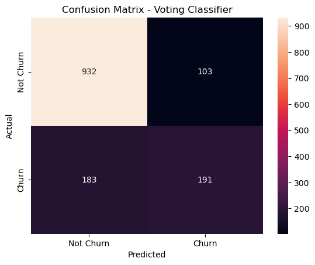

```python
sns.heatmap(cm_vote, annot=True, fmt='d',
            xticklabels=["Not Churn", "Churn"],
            yticklabels=["Not Churn", "Churn"])

plt.xlabel("Predicted")
plt.ylabel("Actual")
plt.title("Confusion Matrix - Voting Classifier")
plt.show()
```